# Cell Ranger Quality Summaries

R Programming

Python Programming

Single-cell RNA-seq

Quality Control

This lesson introduces participants to evaluating the quality of Cell Ranger output for single-cell RNA‑seq experiments. Participants will learn how Cell Ranger processes data, how to interpret the generated QC reports and how to examine key metrics to assess sample quality. The lesson also guides participants through understanding the various output files produced by Cell Ranger and how these results inform the downstream single‑cell analysis.

Authors

Noor Sohail

Meeta Mistry

Will Gammerdinger

Published

July 12, 2026

Keywords

R, Python, Cell Ranger, 10x Genomics

Approximate time: 25 minutes

## Learning objectives

In this lesson, we will:

- Describe how cellranger is run and what the ouputs are
- Review the cellranger generated QC report (web summary HTML)
- Create plots with cellranger metrics

## Overview of lesson

Sequencing data comes in a raw format that requires additional processing in order to be interpretable. In the case single-cell RNA-sequencing, we utilize algorithms to take reads and convert them into a counts matrix. In the process, tools like CellRanger generate intermediate outputs that can give a first-pass look at the quality of the data. In this lesson, we will cover how to run CellRanger and interpret the web summary generated in the process.

## Cellranger

[Cellranger](https://www.10xgenomics.com/support/software/cell-ranger/latest) is a tool created by the company 10x to process single-cell sequencing experiments that were processed with their kits.

The algorithm for the single-cell RNA-seq (scRNA) version of cellranger is described by 10x as follows:

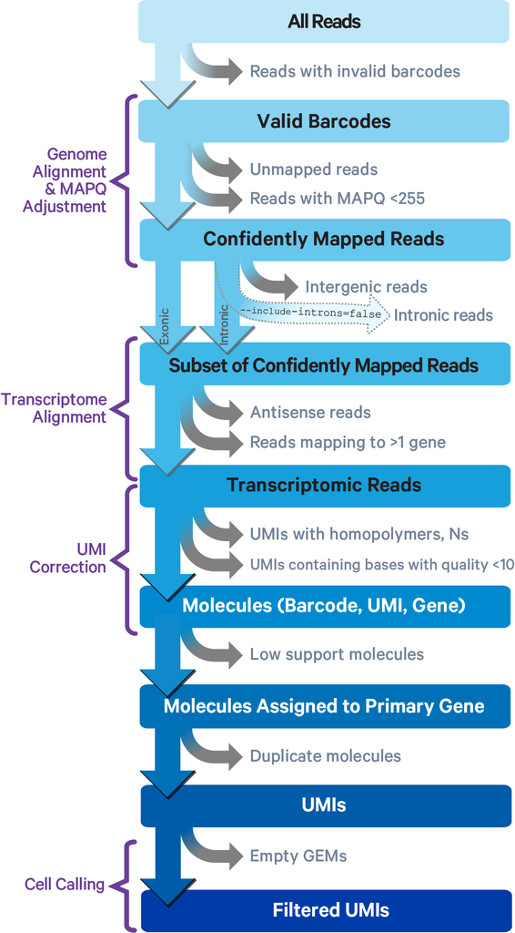

Figure 1: Overview of the Cell Ranger gene expression workflow.  
*Image credit: [10x](https://www.10xgenomics.com/support/software/cell-ranger/latest/algorithms-overview/cr-gex-algorithm)*

The main elements of this pipeline are as follows:

1. Align FASTQ reads against a reference genome
2. Filter low quailty reads and correct cell barcodes/UMIs
3. Collapse on PCR duplicates using UMIs
4. Generate raw counts matrix
5. Identify low quality cells to generate a filtered counts matrix

While the focus of this workshop is scRNA, we also want to point out that there are other cellranger softwares and modes for different types of single-cell experiments.

| Experiment | Experiment description | 10x tool |
| --- | --- | --- |
| RNA | RNA | [cellranger count](https://www.10xgenomics.com/support/software/cell-ranger/latest/analysis/running-pipelines/cr-gex-count) |
| ATAC | ATAC | [cellranger-atac count](https://support.10xgenomics.com/single-cell-atac/software/pipelines/latest/using/count) |
| Multiome | RNA + ATAC | [cellranger-arc count](https://www.10xgenomics.com/support/software/cell-ranger-arc/latest/analysis/single-library-analysis) |
| V(D)J | Clonotyping of T and B cells | [cellranger vdj](https://www.10xgenomics.com/support/software/cell-ranger/latest/analysis/running-pipelines/cr-5p-vdj) |
| Hashtagging | Antibody/oligo tags to differentiate cells after pooling | [cellranger multi](https://www.10xgenomics.com/support/software/cell-ranger/latest/analysis/) |

## Running Cellranger on a High-Performance Computing Cluster

Running cellranger requires a lot of time and computational resources in order to process a single sample. Therefore, having access to a High Performance Computing (HPC) cluster is necessary to run it. Some sequencing cores will automatically process samples with cellranger and provide the outputs to you.

Note that prior to this step, **you must have a cellranger compatible reference genome generated**. If you are working with mouse or human, 10x has pre-generated the reference which can be downloaded from their [website](https://www.10xgenomics.com/support/software/cell-ranger/downloads) for use. If you are using another organism, cellranger has a mode called [mkref](https://www.10xgenomics.com/support/software/cell-ranger/latest/tutorials/cr-tutorial-mr) which will generate everything needed for a reference from the files you supply (GTF and fasta).

Here we are showing an example of how to run `cellranger count` on Harvard’s O2 HPC using SLURM. To run this script, you will have to add additional information, such as:

- The name of the project (the results will be placed in a -older of the same name)
- Path to the FASTQ files from your experiment
- Path to the reference genome

In the following **example script**, you would just have to change the variable specified in the [“Inputs for cellranger” section](https://www.10xgenomics.com/support/software/cell-ranger/latest/analysis/inputs/cr-inputs-overview) on the 10x support site. We have already provided some optimal parameters in terms of runtime and memory for running `cellranger count`.

**You do not need to run this script.**

```r
#!/bin/bash

#SBATCH --partition=short               # Partition name
#SBATCH --time=0-06:00                  # Runtime in D-HH:MM format
#SBATCH --nodes=1                       # Number of nodes (keep at 1)
#SBATCH --ntasks=1                      # Number of tasks per node (keep at 1)
#SBATCH --cpus-per-task=16              # CPU cores requested per task (change for threaded jobs)
#SBATCH --mem=64G                       # Memory needed per node (total)
#SBATCH --error=jobid_%j.err            # File to which STDERR will be written, including job ID
#SBATCH --output=jobid_%j.out           # File to which STDOUT will be written, including job ID
#SBATCH --mail-type=ALL                 # Type of email notification (BEGIN, END, FAIL, ALL)

module load gcc
module load cellranger/7.1.0

local_cores=16
local_mem=64

# Inputs for cellranger
project_name=""                         # Name of output
path_fastq="/path/to/fastq/"             # Path to folder with FASTQ files for one sample
path_ref="/path/to/reference/"           # Path to cellranger compatible reference


cellranger count \
    --id=${project_name} \
    --fastqs=${path_fastq} \
    --transcriptome=${path_ref} \
    --localcores=${local_cores} \
    --localmem=${local_mem}
```

## Cellranger outs

Once cellranger has finished running, there will be a folder titled `outs/` in a directory named after the `project_name` variable set above. Generation of all the following files is expected from a successful completion of the `cellranger counts` pipeline:

```r
├── cloupe.cloupe
├── filtered_feature_bc_matrix
│   ├── barcodes.tsv.gz
│   ├── features.tsv.gz
│   └── matrix.mtx.gz
├── filtered_feature_bc_matrix.h5
├── metrics_summary.csv
├── molecule_info.h5
├── possorted_genome_bam.bam
├── possorted_genome_bam.bam.bai
├── raw_feature_bc_matrix
│   ├── barcodes.tsv.gz
│   ├── features.tsv.gz
│   └── matrix.mtx.gz
├── raw_feature_bc_matrix.h5
└── web_summary.html
```

## Web summary HTML Report

The Web Summary HTML file is a great resource for looking at the basic quality of your sample before starting on an analysis. 10x has a [page describing each metric](https://www.10xgenomics.com/analysis-guides/quality-assessment-using-the-cell-ranger-web-summary) in depth. There are two pages/tabs included in a scRNA report titled “Summary” and “Gene Expression”.

We have included these Web Summary files for the control and stimulated samples your project `data` folder. You can click on them to open them in your web browser.

**Older versions of 10x kits**

Some of the values in these reports will be slightly different from current standards, as these samples were generated using the version 1 chemistry kit and optimization have been made since then.

### Summary

At the top of the `Summary` tab, under the `Alerts` header, will be a list of warnings and messages on the quality/important information about the sample. These messages are very informative on what may have gone wrong with the sample or other flags that can be set in the `cellranger count` run to gain better results.

Underneath the `Summary` tab, in green text, are the estimated number of high quality cells in the sample, average reads per cells, and median genes per cell. The number of cells will vary depending on how many were loaded in sample preparation, but some general recommendations are provided below:

- 500 cells is the **lower limit** for a good quality sample.
- 10x also recommends a minimum of 20,000 reads per cell on average.
- **The median genes per cell varies widely** across samples as it depends on sequencing depth and cell type, making it difficult to establish a good minimal value.

The remaining 4 sections include various metrics that describe the overall quality of the sample. *Note that clicking on the grey question mark will show more detailed explanations.*

**Sequencing**

Includes information such as the total number of reads and how many of those reads did not meet the length requirements. Additionally, since all barcodes and UMIs are known values (from the kit used to prep scRNA experiments), we can evaluate what percentage of the barcodes and UMIs belong to that whitelist and are valid.

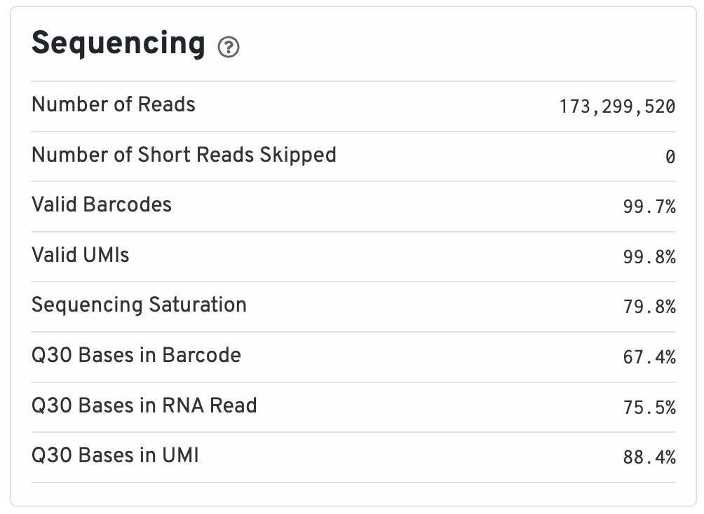

Figure 2: Sequencing metrics panel from the Cell Ranger web summary report.

Ideally, you would like to see >75% for almost all of these values since lower values are indicative of a low quality sequencing run or bad sample quality.

**Mapping**

Percentage of reads that map to different regions of the reference genome as reported by STAR.

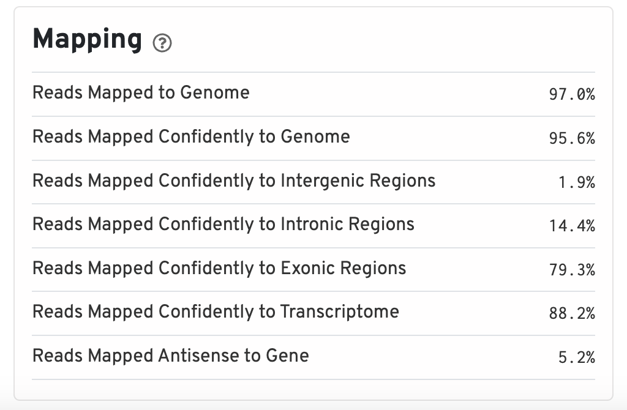

Figure 3: Mapping metrics panel from the Cell Ranger web summary report.

The percent of reads mapped to the genome should be on the higher end, around 85% or higher. Values that are very low could indicate that the reference genome supplied was incorrect or that the sample was problematic. Otherwise, the expectation for a scRNA runs is that the majority of reads will belong to exonic regions. If nuclei were used instead of whole cells, the percentage of reads mapping to intronic regions will be higher (~45%).

**Cells**

Here we can see what an ideal representation of the Barcode Rank Plot looks like. The cells are sorted by the number of UMIs found in the cell to differentiate empty droplets/low quality cells (background) from actual cells.

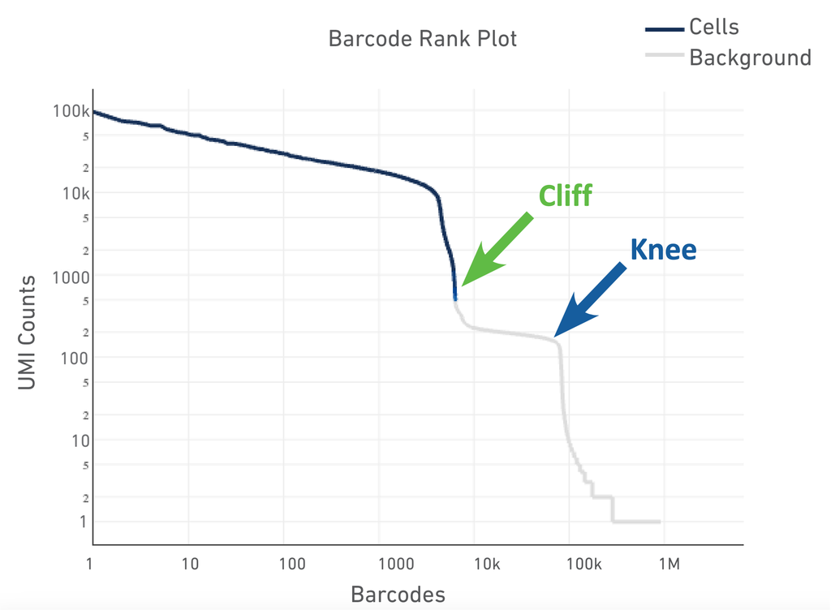

Figure 4: Example barcode rank plot from the Cell Ranger web summary report.  
*Image credit: [10x](https://cdn.10xgenomics.com/image/upload/v1660261286/support-documents/CG000329_TechnicalNote_InterpretingCellRangerWebSummaryFiles_RevA.pdf)*

The shape of these plots can indicate a few different things about the sample:

- **Typical**: Clear cliff and knee with separation between cells and background.
- **Heterogeneous**: Bimodal plot with 2 cliffs and knees, with a clear divide between cells and background.
- **Compromised**: Round curve with a steep drop-off at the end which indicated low quality due to many factors.
- **Compromised**: Defined cliff and knee, but with few barcodes detected could be due to inaccurate cell count or clogging.

This section additionally describes averages and medians for number of genes and reads in the sample.

**Sample**

The sample section contains important metadata used by cellranger, such as what the Sample ID and the path used for the reference. The chemistry version (which 10x kit was used) and intron flags are also stored here. This information is useful for reproducibility reasons, as the version of cellranger used is also kept.

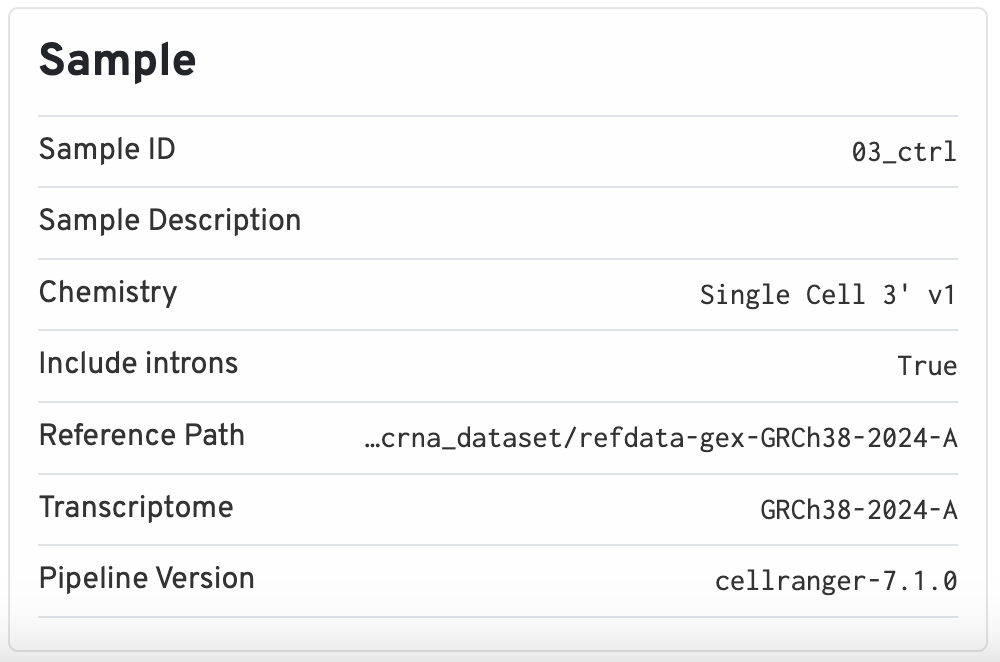

Figure 5: Sample metadata panel from the Cell Ranger web summary report.

### Gene Expression

The “Gene Expression” tab contains information downstream of the basic QC, such as:

**t-SNE Projection**

Dotplot showing the t-SNE projection of filtered cells colored by UMI counts and clusters. The report allows you to select various values of K for the K-means clustering, showing different groupings that can be generated from the data.

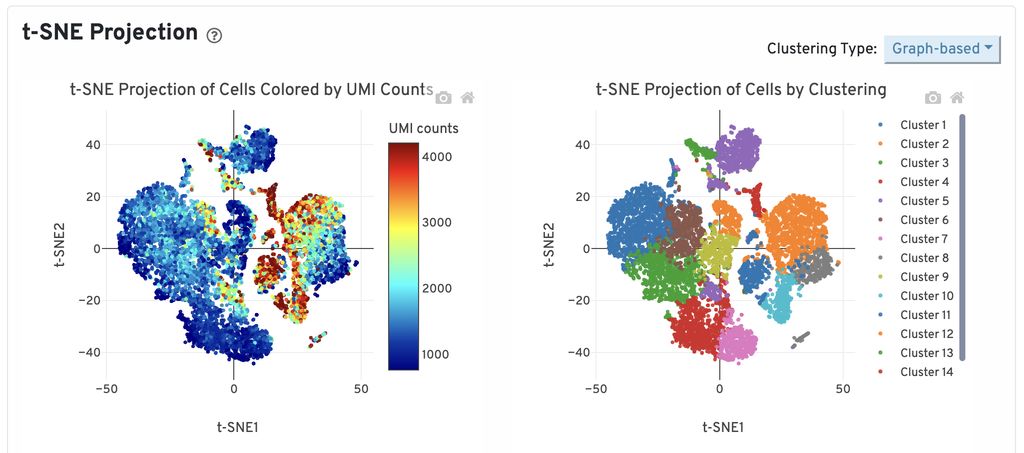

Figure 6: t-SNE projection panels from the Cell Ranger web summary report.

Later in the workshop we will spend more time on the intricacies of clustering. The requirements for this QC report would be to see clear separation of cells into groups with defined clusters - representing different cell types.

**Top Features by Cluster**

This table shows the log2 fold-change and p-value for each gene and cluster after a differential expression analysis is run.

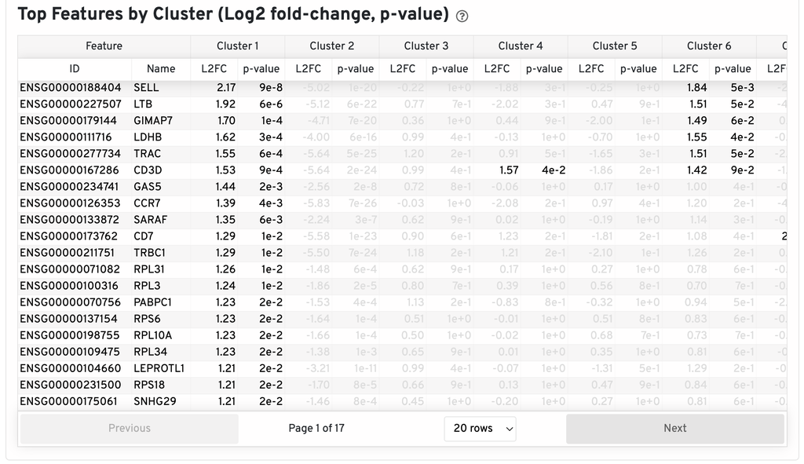

Figure 7: Top features by cluster (log2 fold-change, p-value) table from the Cell Ranger web summary report.

These top genes per cluster can give a brief peek into the cell type distribution of the sample. If no expected cell type marker genes appear or mitochondrial/ribosomal genes show up frequently, this can be indicative of something wrong with the sample.

**Sequencing Saturation and Median Genes per Cell**

The sequencing saturation plot is a measure of library complexity. In scRNA, more genes can be detected with higher sequencing depth. At a point, you reach sequencing saturation where you do not gain any more meaningful insights which is what the dotted line represents here.

Similar to the sequencing saturation plot, looking at the median gene per cells against mean reads per cell will indicate if your have over or under-sequenced. The slope near the endpoint can be used to determine how much benefit would be gained from sequencing more deeply.

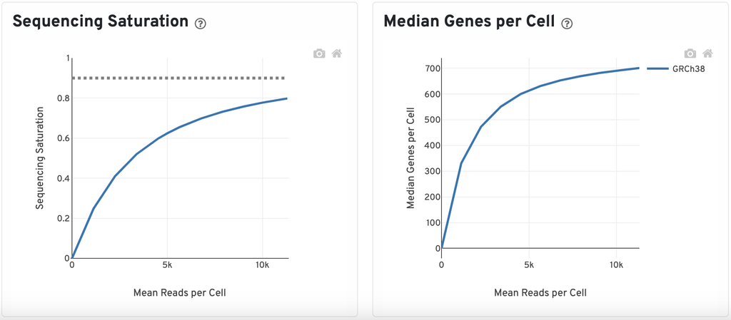

Figure 8: Sequencing saturation and median genes per cell plots from the Cell Ranger web summary report.

## Metrics evaluation

Many of the core pieces of information from the web summary are stored in the `metrics_summary.csv`. As this is a csv file, we can read it into R and generate plots to include in reports on the general quality of the samples.

We have included these csv files for the control and stimulated samples in your **`data` directory**:

- Control sample `metrics.csv` file (`ctrl_metrics_summary.csv`)
- Stimulated sample `metrics.csv` file (`stim_metrics_summary.csv`)

**R**

```r
## Cellranger metrics evaluation

# Load libraries
library(tidyverse)
library(reshape2)
library(plyr)

# Names of samples (same name as folders stored in data)
samples <- c("ctrl", "stim")

# Loop over each sample and read the metrics summary in
metrics <- list()
for (sample in samples) {
    path_csv <- paste0("data/cellranger_outs/", sample, "_metrics_summary.csv")
    df <- read.csv(path_csv)
    rownames(df) <- sample
    df$sample <- sample
    metrics[[sample]] <- df
}
# Concatenate each sample metrics together
metrics <- ldply(metrics, rbind)

# Remove periods and percentages to make the values numeric
metrics <- metrics %>%
  column_to_rownames(".id") %>%
  mutate(across(everything(), parse_number(str_replace(., ",", "")))) %>%
  mutate(across(everything(), parse_number(str_replace(., "%", ""))))
```

The information available in this file include:

```r
colnames(metrics)
```

```
 [1] "Estimated.Number.of.Cells"
 [2] "Mean.Reads.per.Cell"
 [3] "Median.Genes.per.Cell"
 [4] "Number.of.Reads"
 [5] "Valid.Barcodes"
 [6] "Sequencing.Saturation"
 [7] "Q30.Bases.in.Barcode"
 [8] "Q30.Bases.in.RNA.Read"
 [9] "Q30.Bases.in.UMI"
[10] "Reads.Mapped.to.Genome"
[11] "Reads.Mapped.Confidently.to.Genome"
[12] "Reads.Mapped.Confidently.to.Intergenic.Regions"
[13] "Reads.Mapped.Confidently.to.Intronic.Regions"
[14] "Reads.Mapped.Confidently.to.Exonic.Regions"
[15] "Reads.Mapped.Confidently.to.Transcriptome"
[16] "Reads.Mapped.Antisense.to.Gene"
[17] "Fraction.Reads.in.Cells"
[18] "Total.Genes.Detected"
[19] "Median.UMI.Counts.per.Cell"
[20] "sample"
```

With all of this information available as a dataframe, we can use ggplot to visualize these values. As an example of how this information can be used, we can display what percentage of reads map to the various parts of the genome (Intergentic, Intronic, and Exonic).

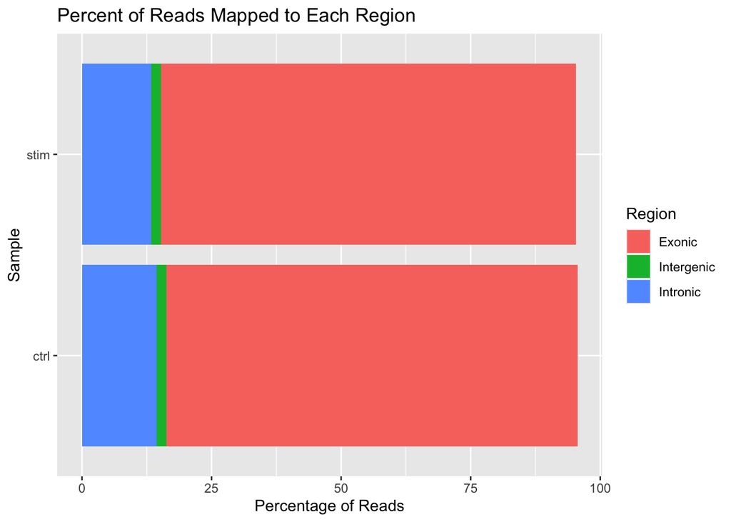

Figure 9: Mapping percentage of reads to different regions of the genome.

```r
# Columns of interest
cols <- c("Reads.Mapped.Confidently.to.Intergenic.Regions",
          "Reads.Mapped.Confidently.to.Intronic.Regions",
          "Reads.Mapped.Confidently.to.Exonic.Regions",
          "sample")

# Data wrangling to sculpt dataframe in a ggplot friendly manner
df <- metrics %>%
    select(all_of(cols)) %>%
    melt(id.vars="sample") %>%
    mutate(variable = str_replace_all(variable, "Reads.Mapped.Confidently.to.", "")) %>%
    mutate(variable = str_replace_all(variable, ".Regions", "")) %>%
    mutate(value = str_replace_all(value, "%", "")) %>% # Remove % from value
    mutate(value = as.numeric(value)) # Make percentage numeric

# ggplot code to make a barplot
df %>% ggplot() +
    geom_bar(
        aes(x = sample, y = value, fill = variable),
        position = "stack",
        stat = "identity") +
    coord_flip() +
    labs(
        x = "Sample",
        y = "Percentage of Reads",
        title = "Percent of Reads Mapped to Each Region",
        fill = "Region")
```

**Python**

```python
# Cellranger metrics evaluation
# Load packages
import os
import pandas as pd
import numpy as np
import matplotlib.pyplot as plt

# Names of samples (same name as folders stored in data)
samples = ["ctrl", "stim"]

# Loop over each sample and read the metrics summary in
metrics_list = []
for sample in samples:
    path_csv = f"data/cellranger_outs/{sample}_metrics_summary.csv"
    df = pd.read_csv(path_csv)
    # Add a sample column
    df["sample"] = sample
    metrics_list.append(df)

# Concatenate each sample's metrics together
metrics = pd.concat(metrics_list, axis=0, ignore_index=False)
```

The information available in this file include:

```python
# Show the column names in the metrics dataframe
metrics.columns
```

```
Index(['Estimated Number of Cells', 'Mean Reads per Cell',
       'Median Genes per Cell', 'Number of Reads', 'Valid Barcodes',
       'Sequencing Saturation', 'Q30 Bases in Barcode',
       'Q30 Bases in RNA Read', 'Q30 Bases in UMI', 'Reads Mapped to Genome',
       'Reads Mapped Confidently to Genome',
       'Reads Mapped Confidently to Intergenic Regions',
       'Reads Mapped Confidently to Intronic Regions',
       'Reads Mapped Confidently to Exonic Regions',
       'Reads Mapped Confidently to Transcriptome',
       'Reads Mapped Antisense to Gene', 'Fraction Reads in Cells',
       'Total Genes Detected', 'Median UMI Counts per Cell', 'sample'],
      dtype='str')
```

With all of this information available as a dataframe, we can use pandas to visualize these values. As an example of how this information can be used, we can display what percentage of reads map to the various parts of the genome (Intergentic, Intronic, and Exonic).

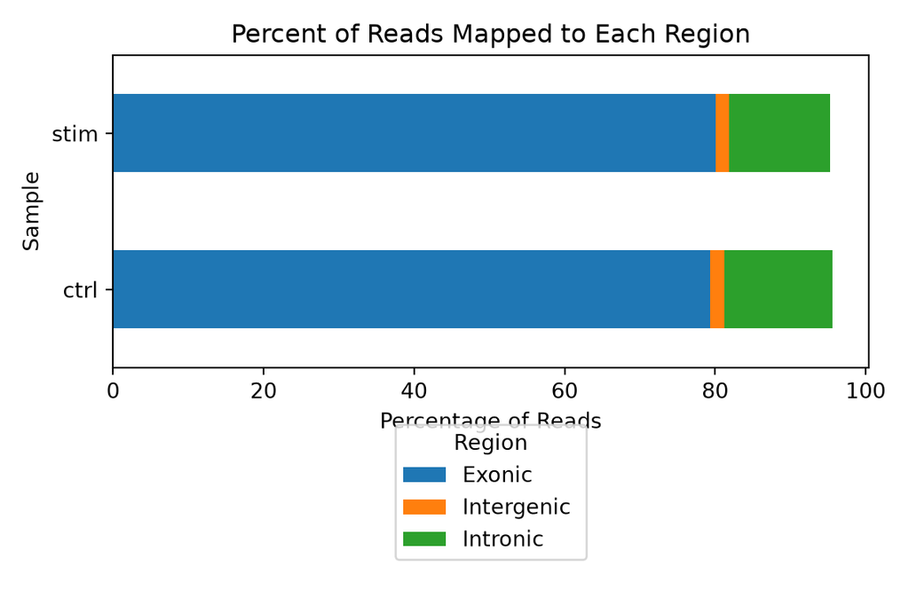

Figure 10: Mapping percentage of reads to different regions of the genome.

```python
# Columns of interest
cols = [
    "Reads Mapped Confidently to Intergenic Regions",
    "Reads Mapped Confidently to Intronic Regions",
    "Reads Mapped Confidently to Exonic Regions",
    "sample",
]

# Grab columns of interest
df = metrics[cols].copy()

# Melt dataframe
df_long = df.melt(
    id_vars="sample",
    var_name="variable",
    value_name="value"
)

# Only keep genomic region name
df_long["variable"] = (
    df_long["variable"]
    .str.replace("Reads Mapped Confidently to ", "", regex=False)
    .str.replace("Regions", "", regex=False)
)

# Remove "%" from percentage column
df_long["value"] = df_long["value"].str.rstrip("%").astype(float)

# Pivot for stacked horizontal bar plot
df_pivot = df_long.pivot(index="sample", columns="variable", values="value")

# Create stacked horizontal bar plot (similar to ggplot + coord_flip)
fig, ax = plt.subplots(figsize=(6, 4))

df_pivot.plot(
    kind="barh",
    stacked=True,
    ax=ax
)

ax.set_xlabel("Percentage of Reads")
ax.set_ylabel("Sample")
ax.set_title("Percent of Reads Mapped to Each Region")
ax.legend(title="Region",
          loc="upper center",
          bbox_to_anchor=(0.5, -0.15))

plt.tight_layout()
plt.show()
```

## Matrix folders

The most important files that are generated during this cellranger run are the two matrix folders, which contain the count matrices from the experiment:

- `raw_feature_bc_matrix`
- `filtered_feature_bc_matrix`

In the **next lesson, we will use `raw_feature_bc_matrix`** to load the counts into Seurat. You can similarly do the same with `filtered_feature_bc_matrix`, the difference being that the filtered matrix has removed cells that cellranger determined as low quality using a variety of different tools. We chose to start with the raw counts matrix in this lesson so that you can better see what metrics are used to determine which cells are considered high quality.

Next Lesson >>

Back to Schedule